# Project: Dr. Semmelweis and the Importance of Handwashing

Ceren Ünal

2024-05-30

# 1 Import Data

```r
yearly_deaths_by_clinic <- read.csv("data/yearly_deaths_by_clinic.csv")
monthly_deaths_clinic_1 <- read.csv("data/monthly_deaths.csv")
```

## 1.1 About the dataset

Hungarian physician Dr. Ignaz Semmelweis worked at the Vienna General Hospital with childbed fever patients. Childbed fever is a deadly disease affecting women who have just given birth, and in the early 1840s, as many as 10% of the women giving birth died from it at the Vienna General Hospital. Dr.Semmelweis discovered that it was the contaminated hands of the doctors delivering the babies, and on June 1st, 1847, he decreed that everyone should wash their hands, an unorthodox and controversial request; nobody in Vienna knew about bacteria.

In this project, we reanalyze the data that made Semmelweis discover the importance of handwashing and its impact on the hospital.

### 1.1.1 yearly_deaths_by_clinic

*yearly_deaths_by_clinic.csv* contains the number of women giving birth at the two clinics at the Vienna General Hospital between the years 1841 and 1846.

**Column:** Description  
**year:** Years (1841-1846)  
**births:** Number of births  
**deaths:** Number of deaths  
**clinic:** Clinic 1 or clinic 2

### 1.1.2 monthly_deaths

*monthly_deaths.csv* contains data from ‘Clinic 1’ of the hospital where most deaths occurred.

**Column:** Description  
**date:** Date (YYYY-MM-DD)  
**births:** Number of births  
**deaths:** Number of deaths

# 2 Explore Data

```r
library(tidyverse)
```

## 2.1 Explore the number of birth and deaths by clinic in each year

```r
glimpse(yearly_deaths_by_clinic)
```

```
## Rows: 12
## Columns: 4
## $ year   <int> 1841, 1842, 1843, 1844, 1845, 1846, 1841, 1842, 1843, 1844, 184…
## $ births <int> 3036, 3287, 3060, 3157, 3492, 4010, 2442, 2659, 2739, 2956, 324…
## $ deaths <int> 237, 518, 274, 260, 241, 459, 86, 202, 164, 68, 66, 105
## $ clinic <chr> "clinic 1", "clinic 1", "clinic 1", "clinic 1", "clinic 1", "cl…
```

We have 12 observations and 4 variables. 3 are numeric, 1 is a character.

```r
summary(yearly_deaths_by_clinic)
```

```
##       year          births         deaths         clinic
##  Min.   :1841   Min.   :2442   Min.   : 66.0   Length:12
##  1st Qu.:1842   1st Qu.:2902   1st Qu.:100.2   Class :character
##  Median :1844   Median :3108   Median :219.5   Mode  :character
##  Mean   :1844   Mean   :3153   Mean   :223.3
##  3rd Qu.:1845   3rd Qu.:3338   3rd Qu.:263.5
##  Max.   :1846   Max.   :4010   Max.   :518.0
```

The data set covers years 1841-1846. There are 3153 births and 223 deaths at the clinics on average per year.

```r
yearly_deaths_by_clinic %>%
  group_by(clinic) %>%
  summarise(sum(births),sum(deaths))
```

| clinic | sum(births) | sum(deaths) |
| --- | --- | --- |
| clinic 1 | 20042 | 1989 |
| clinic 2 | 17791 | 691 |

Clinic 1 seem to have more cases overall, as well as a higher death rate.

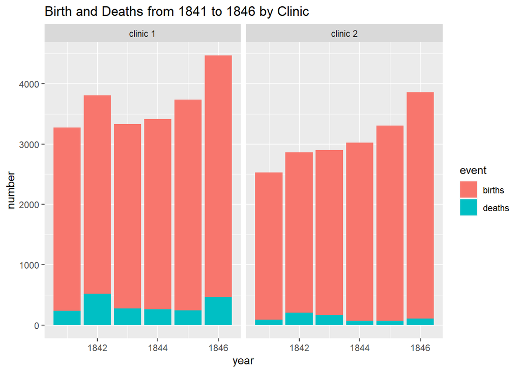

```r
yearly_deaths_by_clinic %>%
  gather(key = event, value = number, births:deaths, factor_key=TRUE) %>% #wide to long transformation
  ggplot(aes(year, number, fill = event)) +
  geom_col(position = "stack") +
  facet_wrap(~clinic) +
  labs(title = "Birth and Deaths from 1841 to 1846 by Clinic")
```

Births seem to have increased in both clinics (with Clinic 1 generally having more cases), but there doesn’t seem to be a clear trend in the number of deaths. At a glance, it looks like Clinic 2 generally has a lower number of deaths, with the maternal death rate decreasing by year.

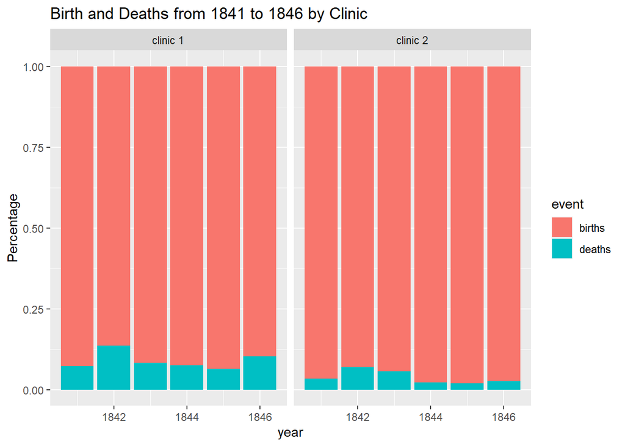

```r
yearly_deaths_by_clinic %>%
  gather(key = event, value = number, births:deaths, factor_key=TRUE) %>% #wide to long transformation
  ggplot(aes(year, number, fill = event)) +
  geom_col(position = "fill") +
  facet_wrap(~clinic) +
  labs(title = "Birth and Deaths from 1841 to 1846 by Clinic", y = "Percentage")
```

Looking at the percent stacked bar chart, we confirm that Clinic 2 does seem to have significantly decreased its death rate after 1843. Clinic 1 has a less impressive downwards trend.

## 2.2 Explore the number of birth and deaths by month in Clinic 1

```r
glimpse(monthly_deaths_clinic_1)
```

```
## Rows: 98
## Columns: 3
## $ date   <chr> "1841-01-01", "1841-02-01", "1841-03-01", "1841-04-01", "1841-0…
## $ births <int> 254, 239, 277, 255, 255, 200, 190, 222, 213, 236, 235, 307, 311…
## $ deaths <int> 37, 18, 12, 4, 2, 10, 16, 3, 4, 26, 53, 64, 38, 27, 26, 10, 18,…
```

There are 98 observations and 3 variables in the data set 2 are numeric, 1 is character. Date is a character variable, which will need fixing.

```r
summary(monthly_deaths_clinic_1)
```

```
##      date               births          deaths
##  Length:98          Min.   :190.0   Min.   : 0.00
##  Class :character   1st Qu.:242.5   1st Qu.: 8.00
##  Mode  :character   Median :264.0   Median :16.50
##                     Mean   :267.0   Mean   :22.47
##                     3rd Qu.:292.8   3rd Qu.:36.75
##                     Max.   :406.0   Max.   :75.00
```

267 births and 22.47 deaths occur in the clinics on average per month.  
However, we can’t tell the max and min dates in this data set, since date is a character.

### 2.2.1 Wrangling the date variable

```r
monthly_deaths_clinic_1 <- monthly_deaths_clinic_1 %>%
  mutate(date = ymd(date))

summary(monthly_deaths_clinic_1)
```

```
##       date                births          deaths
##  Min.   :1841-01-01   Min.   :190.0   Min.   : 0.00
##  1st Qu.:1843-02-08   1st Qu.:242.5   1st Qu.: 8.00
##  Median :1845-02-15   Median :264.0   Median :16.50
##  Mean   :1845-02-11   Mean   :267.0   Mean   :22.47
##  3rd Qu.:1847-02-22   3rd Qu.:292.8   3rd Qu.:36.75
##  Max.   :1849-03-01   Max.   :406.0   Max.   :75.00
```

After mutating the date variable to date data type, we can see that the data set covers years 1841-1849. 3 more years than the yearly_deaths_by_clinic data set.

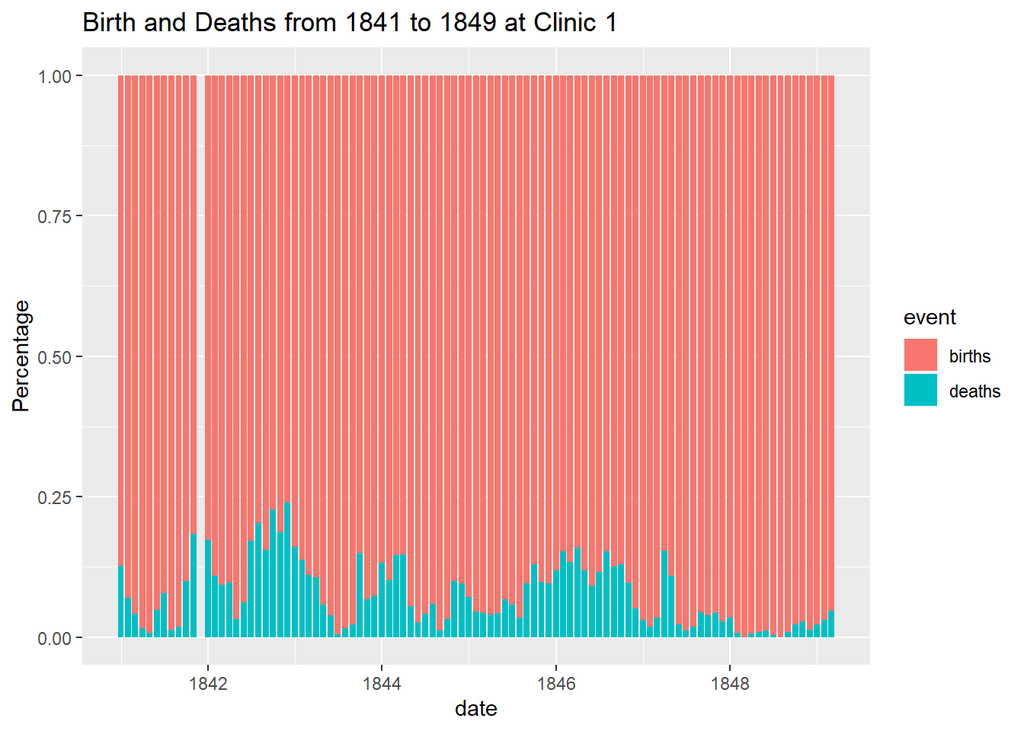

```r
monthly_deaths_clinic_1  %>%
  gather(key = event, value = number, births:deaths, factor_key=TRUE) %>% #wide to long transformation
  ggplot(aes(date, number, fill = event)) +
  geom_col(position = "fill") +
  labs(title = "Birth and Deaths from 1841 to 1849 at Clinic 1", y = "Percentage")
```

There seems to be some missing monthly data in 1841. Regardless, this monthly chart shows a very significant decrease in death rate in Clinic 1 after 1847, which the yearly data set did not cover.

# 3 Analyze Data

Now that we have completed a basic exploration of our two data sets, we can start working on the actual question.

## 3.1 Question: Did Handwashing Help Decrease the Maternal Death Rates?

On June 1st, 1847, Dr. Semmelweis decreed everyone should wash their hands before delivering babies, which would prevent maternal deaths caused by contamination from doctors’ hands.

To answer this question, we will be using the “monthly_deaths_clinic_1” data set, which gives us the birth and death numbers after 1846 by month, but is limited to Clinic 1, where most events occur.

### 3.1.1 Mutate New Columns to Data Set

```r
monthly_deaths_clinic_1 <- monthly_deaths_clinic_1 %>%
mutate(handwashing_started = date >= "1847-06-01",
       proportion_deaths = deaths / births)
```

“handwashing_started” variable will help us better visualize the change in death rate over the years. “proportion_deaths” variable will enable us to use a line plot.

### 3.1.2 Visualization

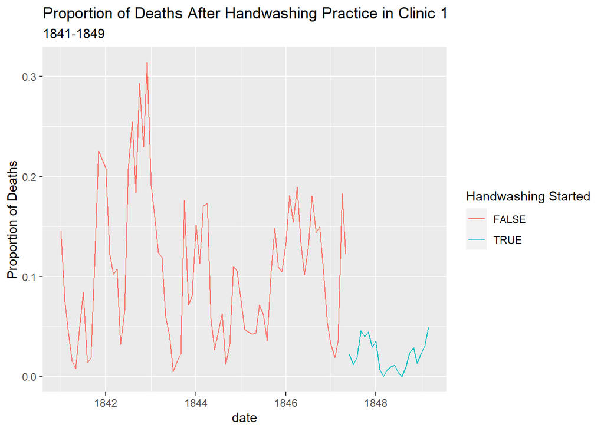

```r
monthly_deaths_clinic_1 %>%
ggplot(aes(date, proportion_deaths, color = handwashing_started)) +
geom_line() +
labs (title = "Proportion of Deaths After Handwashing Practice in Clinic 1",
     subtitle = "1841-1849",
     y= "Proportion of Deaths",
     color = "Handwashing Started")
```

The line plot with the boolean variable demonstrates a very sharp decrease in death rate at Clinic 1, with the introduction of the hand washing practice.

### 3.1.3 Summary

```r
monthly_summary <- monthly_deaths_clinic_1  %>%
  group_by(handwashing_started) %>%
  summarize(mean_proportion_deaths = mean(proportion_deaths))

monthly_summary
```

| handwashing_started | mean_proportion_deaths |
| --- | --- |
| FALSE | 0.10504998 |
| TRUE | 0.02109338 |

The comparison of before and after hand washing shows the average death rate has dropped from 10% to 2%, achieving an all time low based on these records.

# 4 Conclusion

Dr. Semmelweis’ was correct in his hypothesis that hand washing will decrease mothers’ death rate during child birth. The decreased chance of contamination from doctors’ hands has helped women avoid getting infected with childbed fever, and more survived childbirth than ever.